# HW3

Shihao Yang

9/27/2021

# My github repo: (https://github.com/Hawk9808/433HW)

```r
orig_data <- flights
```

#### 1. How many flights have a missing dep_time? What other variables are missing? What might these rows represent?

```r
#How many flights have a missing dep_time?
# orig_data %>%
#   summarise(miss_dep = sum(is.na(dep_time)))

#How many flights have a missing dep_time? What other variables are missing?
summary(flights)
```

```
##       year          month             day           dep_time    sched_dep_time
##  Min.   :2013   Min.   : 1.000   Min.   : 1.00   Min.   :   1   Min.   : 106
##  1st Qu.:2013   1st Qu.: 4.000   1st Qu.: 8.00   1st Qu.: 907   1st Qu.: 906
##  Median :2013   Median : 7.000   Median :16.00   Median :1401   Median :1359
##  Mean   :2013   Mean   : 6.549   Mean   :15.71   Mean   :1349   Mean   :1344
##  3rd Qu.:2013   3rd Qu.:10.000   3rd Qu.:23.00   3rd Qu.:1744   3rd Qu.:1729
##  Max.   :2013   Max.   :12.000   Max.   :31.00   Max.   :2400   Max.   :2359
##                                                  NA's   :8255
##    dep_delay          arr_time    sched_arr_time   arr_delay
##  Min.   : -43.00   Min.   :   1   Min.   :   1   Min.   : -86.000
##  1st Qu.:  -5.00   1st Qu.:1104   1st Qu.:1124   1st Qu.: -17.000
##  Median :  -2.00   Median :1535   Median :1556   Median :  -5.000
##  Mean   :  12.64   Mean   :1502   Mean   :1536   Mean   :   6.895
##  3rd Qu.:  11.00   3rd Qu.:1940   3rd Qu.:1945   3rd Qu.:  14.000
##  Max.   :1301.00   Max.   :2400   Max.   :2359   Max.   :1272.000
##  NA's   :8255      NA's   :8713                  NA's   :9430
##    carrier              flight       tailnum             origin
##  Length:336776      Min.   :   1   Length:336776      Length:336776
##  Class :character   1st Qu.: 553   Class :character   Class :character
##  Mode  :character   Median :1496   Mode  :character   Mode  :character
##                     Mean   :1972
##                     3rd Qu.:3465
##                     Max.   :8500
##
##      dest              air_time        distance         hour
##  Length:336776      Min.   : 20.0   Min.   :  17   Min.   : 1.00
##  Class :character   1st Qu.: 82.0   1st Qu.: 502   1st Qu.: 9.00
##  Mode  :character   Median :129.0   Median : 872   Median :13.00
##                     Mean   :150.7   Mean   :1040   Mean   :13.18
##                     3rd Qu.:192.0   3rd Qu.:1389   3rd Qu.:17.00
##                     Max.   :695.0   Max.   :4983   Max.   :23.00
##                     NA's   :9430
##      minute        time_hour
##  Min.   : 0.00   Min.   :2013-01-01 05:00:00
##  1st Qu.: 8.00   1st Qu.:2013-04-04 13:00:00
##  Median :29.00   Median :2013-07-03 10:00:00
##  Mean   :26.23   Mean   :2013-07-03 05:22:54
##  3rd Qu.:44.00   3rd Qu.:2013-10-01 07:00:00
##  Max.   :59.00   Max.   :2013-12-31 23:00:00
##
```

> *As we can see from the above summary, 8255 flights have a missing `dep_time`, 8255 have a missing `dep_delay`, 8713 have a missing `arr_time`, 9430 have a missing `arr_delay`, and 9430 have a missing `air_time`. In a row with missing values, we can expect that this might be a flight that failed to depart or arrive. Also, this missing data could be just normally lost.*

#### 2. Currently dep_time and sched_dep_time are convenient to look at, but hard to compute with because they’re not really continuous numbers. Convert them to a more convenient representation of number of minutes since midnight.

```r
data_mutate <- orig_data %>%
  mutate(dep_time = (dep_time %/% 100) * 60 + (dep_time %% 100),
         sched_dep_time = (sched_dep_time %/% 100) * 60 + (sched_dep_time %% 100))
head(data_mutate)
```

```
## # A tibble: 6 x 19
##    year month   day dep_time sched_dep_time dep_delay arr_time sched_arr_time
##   <int> <int> <int>    <dbl>          <dbl>     <dbl>    <int>          <int>
## 1  2013     1     1      317            315         2      830            819
## 2  2013     1     1      333            329         4      850            830
## 3  2013     1     1      342            340         2      923            850
## 4  2013     1     1      344            345        -1     1004           1022
## 5  2013     1     1      354            360        -6      812            837
## 6  2013     1     1      354            358        -4      740            728
## # ... with 11 more variables: arr_delay <dbl>, carrier <chr>, flight <int>,
## #   tailnum <chr>, origin <chr>, dest <chr>, air_time <dbl>, distance <dbl>,
## #   hour <dbl>, minute <dbl>, time_hour <dttm>
```

#### 3. Look at the number of canceled flights per day. Is there a pattern? Is the proportion of canceled flights related to the average delay? Use multiple dyplr operations, all on one line, concluding with ggplot(aes(x= ,y=)) + geom_point()

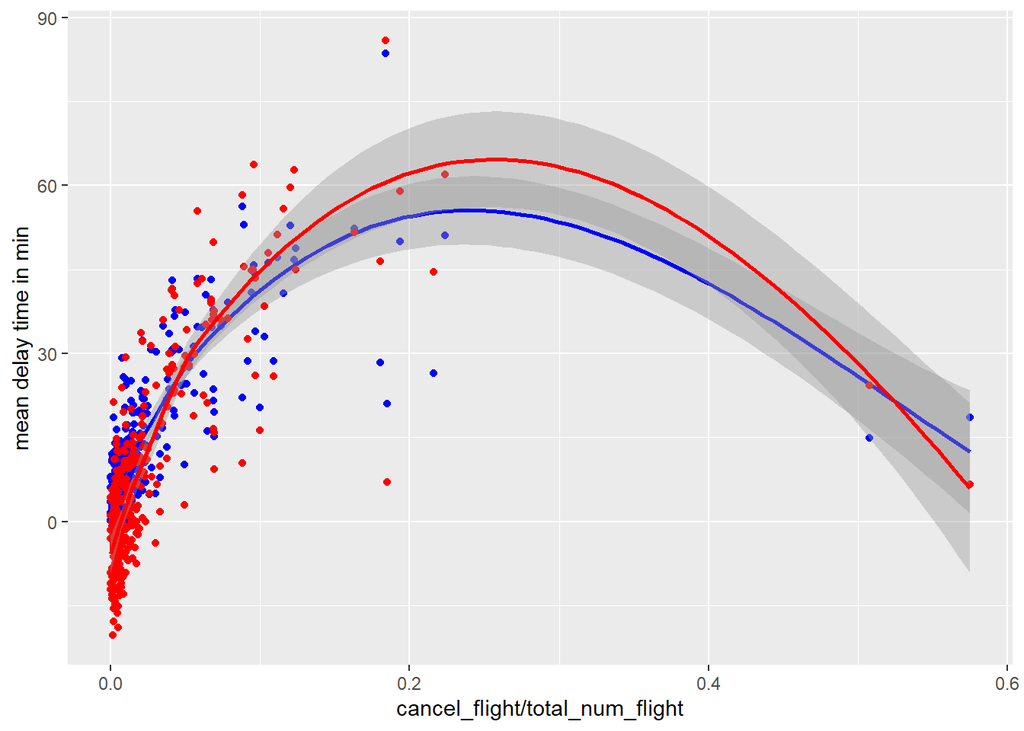

```r
data_3 <- orig_data %>%
  mutate(dep_date = lubridate::make_datetime(year, month, day)) %>%#this is consulting from r4ds_solution.
  group_by(dep_date) %>%
  summarise(cancel_flight = sum(is.na(dep_delay)),
            total_num_flight = n(),
            dep_delay_mean = mean(dep_delay,na.rm=TRUE),
            arr_delay_mean = mean(arr_delay,na.rm=TRUE))

ggplot(data = data_3, aes(x= cancel_flight/total_num_flight)) +
  geom_point(aes(y=dep_delay_mean), color='blue') +
  geom_smooth(aes(y=dep_delay_mean), color='blue')+
  geom_point(aes(y=arr_delay_mean), color='red') +
  geom_smooth(aes(y=arr_delay_mean), color='red')+
  ylab('mean delay time in min')
```

> *As we can see from the above graph, in many times, as cancellation rate increase, the average delay of that day also increase.*